# HW6

Author

Jake Grossman

```r
library(tidyverse)
library(tidytext)
library(schrute)
```

# The Office

Let’s continue to work with *The Office* text from the [schrute](https://cran.r-project.org/web/packages/schrute/index.html) package.

```r
library(schrute)
library(tidyverse)
library(tidytext)
library(lexicon)
library(kableExtra)
```

# Sentiment Analysis

```r
office <- schrute::theoffice %>%
  mutate(air_date = as.Date(air_date))

bing <- get_sentiments("bing")

# Episode-level metadata (one row per episode)
episode_meta <- office %>%
  group_by(season, episode) %>%
  summarise(
    episode_name = first(episode_name),
    imdb_rating  = first(imdb_rating),
    air_date     = first(air_date),
    .groups = "drop"
  ) %>%
  arrange(air_date, season, episode)

episode_meta
```

```
# A tibble: 186 × 5
   season episode episode_name      imdb_rating air_date
    <int>   <int> <chr>                   <dbl> <date>
 1      1       1 Pilot                     7.6 2005-03-24
 2      1       2 Diversity Day             8.3 2005-03-29
 3      1       3 Health Care               7.9 2005-04-05
 4      1       4 The Alliance              8.1 2005-04-12
 5      1       5 Basketball                8.4 2005-04-19
 6      1       6 Hot Girl                  7.8 2005-04-26
 7      2       1 The Dundies               8.7 2005-09-20
 8      2       2 Sexual Harassment         8.2 2005-09-27
 9      2       3 Office Olympics           8.4 2005-10-04
10      2       4 The Fire                  8.4 2005-10-11
# ℹ 176 more rows
```

### Over Time

Calculate the sentiment score (positive - negative) for each episode, and plot this variable over time.

```r
episode_sent <- office %>%
  mutate(text = str_to_lower(text)) %>%
  unnest_tokens(word, text) %>%
  inner_join(bing, by = "word") %>%
  count(season, episode, sentiment, name = "n") %>%
  pivot_wider(names_from = sentiment, values_from = n, values_fill = 0) %>%
  mutate(sent_score = positive - negative) %>%
  right_join(episode_meta, by = c("season", "episode")) %>%
  replace_na(list(sent_score = 0, positive = 0, negative = 0)) %>%
  mutate(pos_prop = positive / (positive + negative))

episode_sent
```

```
# A tibble: 186 × 9
   season episode negative positive sent_score episode_name      imdb_rating
    <int>   <int>    <int>    <int>      <int> <chr>                   <dbl>
 1      1       1       74      107         33 Pilot                     7.6
 2      1       2       63      153         90 Diversity Day             8.3
 3      1       3       67      128         61 Health Care               7.9
 4      1       4       65      163         98 The Alliance              8.1
 5      1       5       57      127         70 Basketball                8.4
 6      1       6       51      173        122 Hot Girl                  7.8
 7      2       1       58      135         77 The Dundies               8.7
 8      2       2       86      146         60 Sexual Harassment         8.2
 9      2       3       38      146        108 Office Olympics           8.4
10      2       4       67      122         55 The Fire                  8.4
# ℹ 176 more rows
# ℹ 2 more variables: air_date <date>, pos_prop <dbl>
```

```r
episode_kable <- episode_sent %>%
  select(season, episode_name, imdb_rating, pos_prop) %>%
  arrange(desc(pos_prop)) %>%
  slice_head(n = 10)

episode_kable %>%
  kable() %>%
  kable_minimal() %>%
  collapse_rows(columns = 1, valign = "top") %>%
  kable_styling(
    bootstrap_options = c("striped", "hover"),
    position = "left",
    font_size = 14,
    fixed_thead = TRUE
  )
```

| season | episode_name | imdb_rating | pos_prop |
| --- | --- | --- | --- |
| 2 | Office Olympics | 8.4 | 0.7934783 |
| 6 | Happy Hour | 8.6 | 0.7887324 |
| 1 | Hot Girl | 7.8 | 0.7723214 |
| 5 | Employee Transfer | 8.1 | 0.7683616 |
| 2 | Casino Night | 9.3 | 0.7529880 |
| 8 | Trivia | 7.9 | 0.7528736 |
| 4 | Goodbye, Toby (Parts 1&2) | 9.3 | 0.7513661 |
| 5 | New Boss | 8.3 | 0.7448980 |
| 8 | Mrs. California | 7.7 | 0.7422680 |
| 2 | Take Your Daughter to Work Day | 8.3 | 0.7383721 |

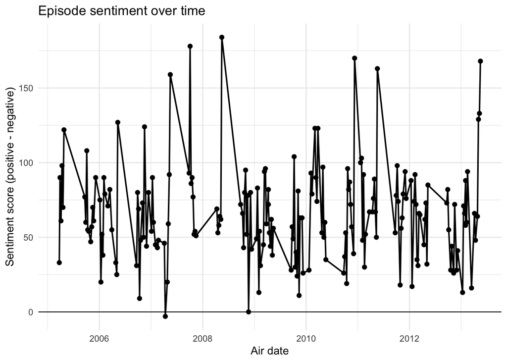

```r
ggplot(episode_sent, aes(x = air_date, y = sent_score)) +
  geom_hline(yintercept = 0, linewidth = 0.4) +
  geom_line(linewidth = 0.7) +
  geom_point(size = 1.7) +
  labs(
    title = "Episode sentiment over time",
    x = "Air date",
    y = "Sentiment score (positive - negative)"
  ) +
  theme_minimal()
```

### By Rating

Create a scatterplot of the `imdb_rating` versus the sentiment score (positive - negative), where the case is again an episode. Decide whether a linear model is a good fit to this relationship (optional, if you have had modeling classes, what model looks best?). Comment on what you find.

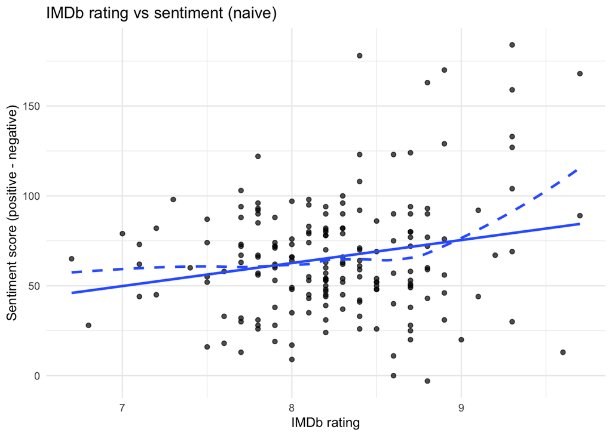

```r
df_rating_naive <- episode_sent %>% filter(!is.na(imdb_rating))

ggplot(df_rating_naive, aes(x = imdb_rating, y = sent_score)) +
  geom_point(alpha = 0.7) +
  geom_smooth(method = "lm", se = FALSE) +
  geom_smooth(method = "loess", se = FALSE, linetype = 2) +
  labs(
    title = "IMDb rating vs sentiment (naive)",
    x = "IMDb rating",
    y = "Sentiment score (positive - negative)"
  ) +
  theme_minimal()
```

```r
m_lm <- lm(sent_score ~ imdb_rating, data = df_rating_naive)
summary(m_lm)
```

```
Call:
lm(formula = sent_score ~ imdb_rating, data = df_rating_naive)

Residuals:
    Min      1Q  Median      3Q     Max
-75.883 -20.843  -1.063  16.917 110.237

Coefficients:
            Estimate Std. Error t value Pr(>|t|)
(Intercept)  -39.759     36.162  -1.099  0.27300
imdb_rating   12.800      4.374   2.927  0.00386 **
---
Signif. codes:  0 '***' 0.001 '**' 0.01 '*' 0.05 '.' 0.1 ' ' 1

Residual standard error: 31.84 on 184 degrees of freedom
Multiple R-squared:  0.04448,   Adjusted R-squared:  0.03928
F-statistic: 8.565 on 1 and 184 DF,  p-value: 0.00386
```

```r
m_poly2 <- lm(sent_score ~ poly(imdb_rating, 2), data = df_rating_naive)
AIC(m_lm, m_poly2)
```

```
        df      AIC
m_lm     3 1819.193
m_poly2  4 1816.364
```

### Sentiment Negation

Identify at least a few negations that change the sentiment values based on the text. Use this to recreate the graphs above (or do this first, then create the graphs).

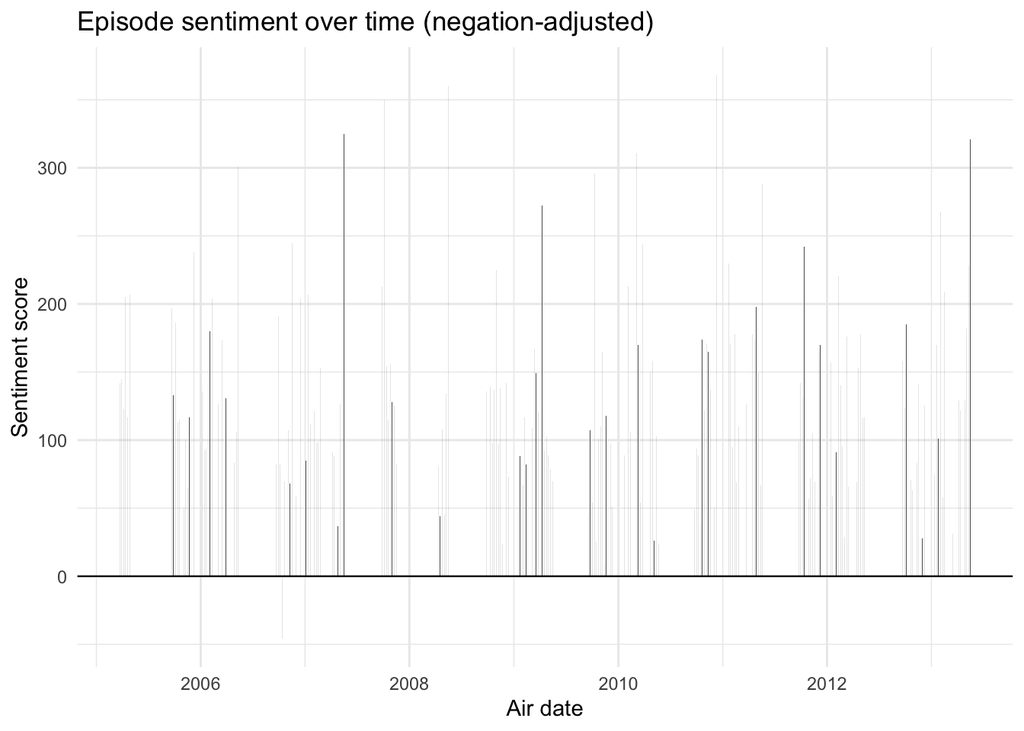

```r
# Define negation words
negation_words <- c("not", "no", "never", "without", "don't", "doesn't",
                    "didn't", "won't", "can't", "cannot", "hardly", "barely")

# Tokenize into bigrams
office_bigrams <- office %>%
  unnest_tokens(bigram, text, token = "ngrams", n = 2) %>%
  separate(bigram, into = c("word1", "word2"), sep = " ")

# Negated sentiment
negated_words <- office_bigrams %>%
  filter(word1 %in% negation_words) %>%
  inner_join(get_sentiments("afinn"), by = c("word2" = "word")) %>%
  mutate(value = -value)

# Non-negated sentiment
normal_sentiment <- office_bigrams %>%
  filter(!word1 %in% negation_words) %>%
  inner_join(get_sentiments("afinn"), by = c("word2" = "word"))

# Combine
adjusted_sentiment <- bind_rows(normal_sentiment, negated_words)

# Summarise by episode, then re-attach episode metadata
episode_sent_negation <- adjusted_sentiment %>%
  group_by(season, episode) %>%
  summarise(sent_score = sum(value), .groups = "drop") %>%
  left_join(episode_meta, by = c("season", "episode"))

ggplot(episode_sent_negation, aes(x = air_date, y = sent_score)) +
  geom_col(width = 0.4) +
  geom_hline(yintercept = 0, linewidth = 0.4) +
  labs(
    title = "Episode sentiment over time (negation-adjusted)",
    x = "Air date",
    y = "Sentiment score"
  ) +
  theme_minimal()
```

```r
episode_kable_neg <- episode_sent_negation %>%
  select(season, episode, sent_score) %>%
  arrange(desc(sent_score)) %>%
  slice_head(n = 10)

episode_kable_neg %>%
  kable() %>%
  kable_minimal() %>%
  collapse_rows(columns = 1, valign = "top") %>%
  kable_styling(
    bootstrap_options = c("striped", "hover"),
    position = "left",
    font_size = 14,
    fixed_thead = TRUE
  )
```

| season | episode | sent_score |
| --- | --- | --- |
| 7 | 11 | 368 |
| 4 | 18 | 360 |
|  | 3 | 350 |
| 3 | 24 | 325 |
| 9 | 24 | 321 |
| 6 | 17 | 311 |
| 2 | 22 | 301 |
| 6 | 4 | 296 |
| 7 | 25 | 288 |
| 3 | 8 | 245 |